fossil

# ODE-MM, dug back up.

Its likelihood runs again, in Python. Figs 2 to 6 and the tables came back from the authors’ saved fits; one pie in Fig. 5C did not.

[Read the code notes](https://github.com/jeonglab-bcm/fossil/tree/main/PMC4081021/figure-reproduction#details)

## Fig. 2

A conversion process fitted by ODE constrained mixture modelling: homogeneous, non-overlapping subpopulations (B to D) and heterogeneous, highly overlapping ones (E to G).

AgreesPython port, saved fits

Published

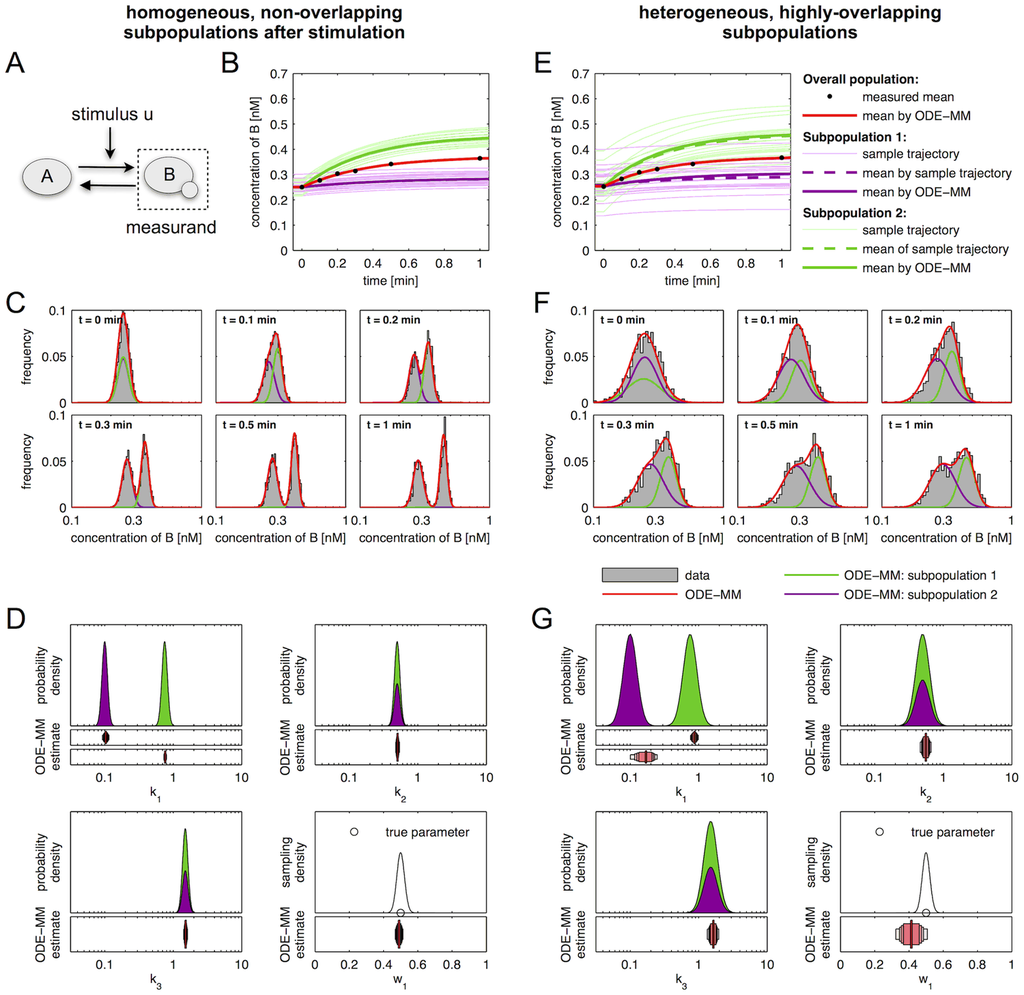

Our run

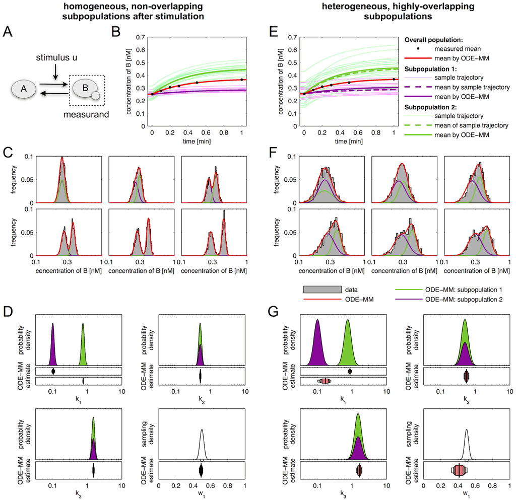

**Pixel size**

4042 × 3931

**2B, ≤4 px both ways**

100% and 100%

**2C, ≤4 px both ways**

91.4% and 99.1%

**2D, ≤4 px both ways**

95.8% and 99.2%

**2E, ≤4 px both ways**

98.2% and 88.8%

**2F, ≤4 px both ways**

96.2% and 99.9%

**2G, ≤4 px both ways**

95.5% and 91%

**Mean |Δ| grey**

1.51

Both scenarios, drawn from the authors’ saved fits. The thin sample trajectories in B and E are 20 seeded draws of ours and are not scored. The dashed means in E averaged 500 random cells in the original; we draw their exact expectation. The interval bars in D and G come from the profile likelihoods the authors saved.

## Fig. 3

NGF-induced Erk1/2 signalling without subpopulations: mean pErk against the data (B), histograms (C) and parameter estimates (D).

AgreesPython port, saved fits

Published

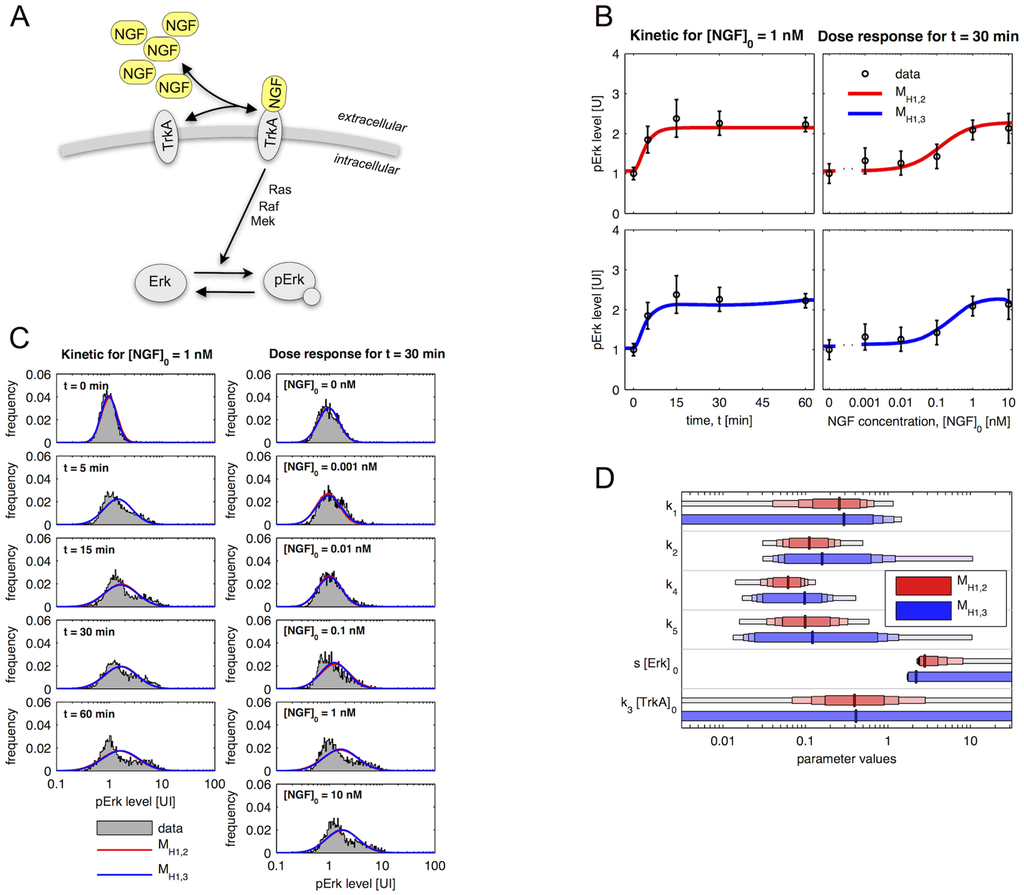

Our run

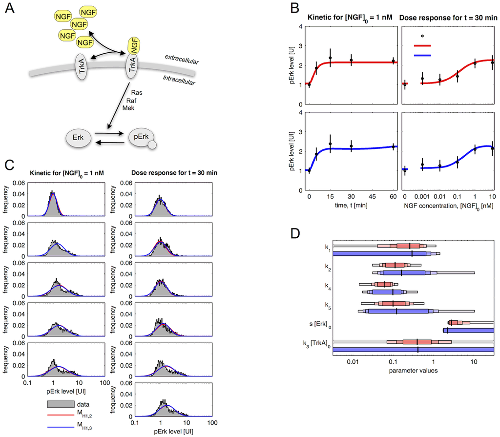

**Pixel size**

4046 × 3537

**3B, ≤4 px both ways**

99.8% and 99.8%

**3C, ≤4 px both ways**

84.3% and 99%

**3D, ≤4 px both ways**

98.6% and 92.1%

**Mean |Δ| grey**

2.59

Pathway model A, M<sub>H1,2</sub> (red) and M<sub>H1,3</sub> (blue). The dose-response curves in B are the state at 60 min, not 30: the data and the fit are at 30 min, but the plotting script reuses the kinetic panel’s time vector (0 to 60 min) and takes its last point. pErk has nearly settled by 30 min, so the curves barely move; we draw them as the script does.

## Fig. 4

The same pathway with two subpopulations that differ in TrkA level: mean pErk (B), histograms (C) and parameter estimates (D).

AgreesPython port, saved fits

Published

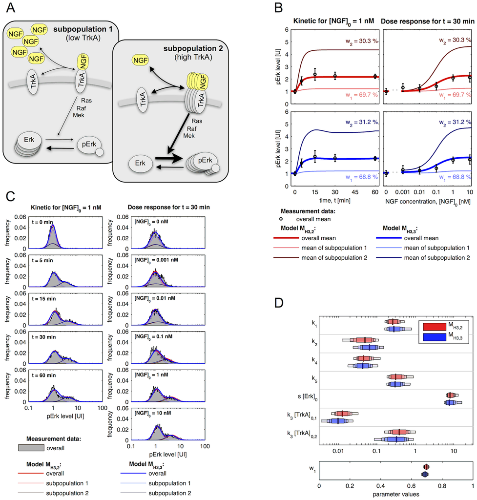

Our run

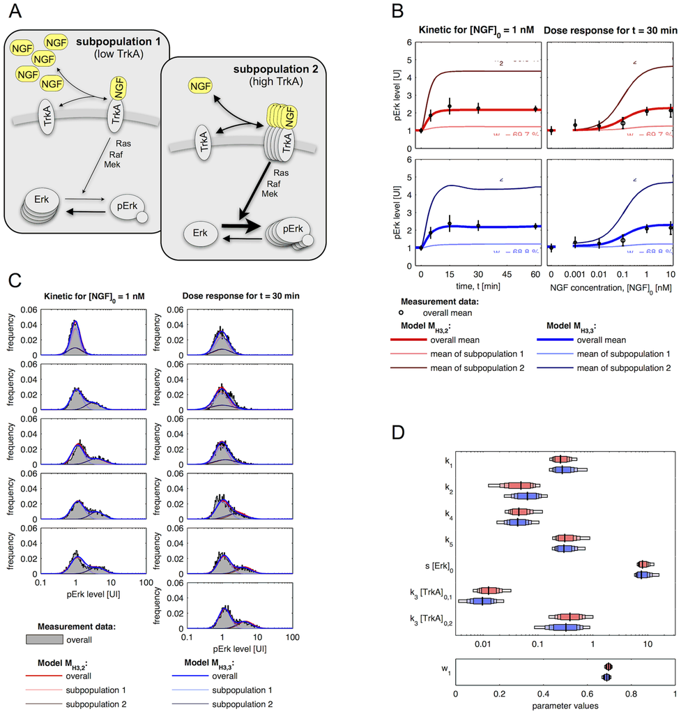

**Pixel size**

4057 × 4251

**4B, ≤4 px both ways**

81.4% and 99.8%

**4C, ≤4 px both ways**

82% and 99.5%

**4D, ≤4 px both ways**

99.4% and 95.3%

**4B, w₁ (red, blue)**

69.7% and 68.8%

**Mean |Δ| grey**

1.84

M<sub>H3,2</sub> (red) and M<sub>H3,3</sub> (blue). The saved fits give the weights printed in B, 69.7% and 68.8%; the coloured “w = …%” labels are left out of the scores. As in Fig. 3, the dose-response curves are drawn at 60 min.

## Fig. 5

Partly agreesPython port, saved fits

Published

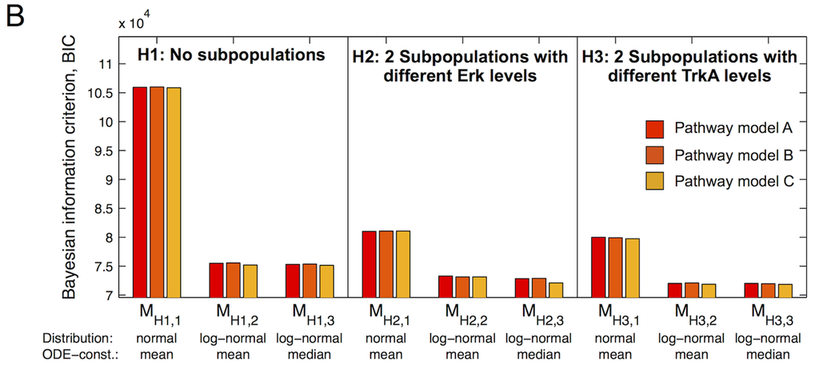

Our run

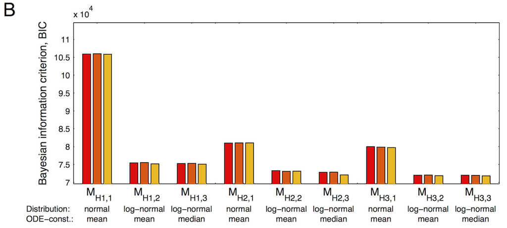

**Pixel size**

3123 × 1405

**5B, ≤4 px both ways**

95.5% and 96.4%

**5B, BIC as in S1 Table 1**

27 of 27

**5C, w₁ ours (A, B, C)**

68.8, 69.8, 70.0%

**5C, w₁ published**

68.8, 71.5, 70.0%

**Mean |Δ| grey**

7.19

Panel B only; A and C are cut from the images. All 27 BIC values equal S1 Table 1 at the printed four digits. In C, w₁ of M<sub>H3,3</sub> is 68.8% for pathway model A and 70.0% for C, as published. For model B the saved fit gives 69.8%, where the pie reads 71.5%; no saved fit of model B gives that.

## Fig. 6

Joint distribution of pErk and total Erk in control cells (A) and after 1 nM NGF for 30 min (B), with a two-component normal mixture.

AgreesPython port of the script

Published

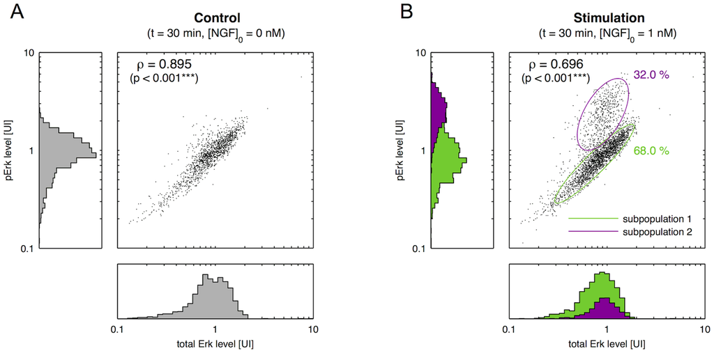

Our run

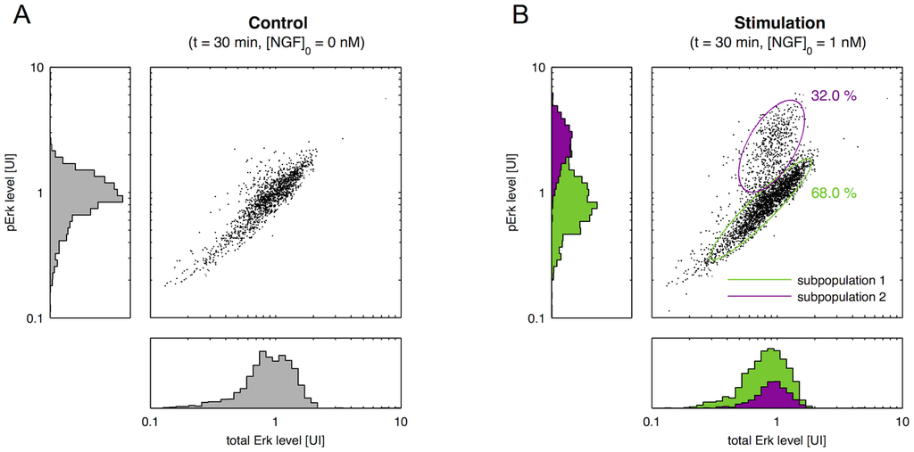

**Pixel size**

2699 × 1336

**6A, ≤4 px both ways**

99.4% and 99.9%

**6B, ≤4 px both ways**

100% and 99.6%

**ρ, control and stimulated**

0.895 and 0.696

**Mixture weights**

68.0 / 32.0%

**Mean |Δ| grey**

2.06

Correlations 0.895 and 0.696, mixture weights 68.0 / 32.0%, as published. MATLAB’s gmdistribution.fit stops EM when the log-likelihood changes by less than 10⁻⁶ of its value, and we stop it the same way; run to convergence, EM gives 68.1 / 31.9%. Panel B plots the control and stimulated cells together, as the script does.

## Tables 1 and 2

Model selection for the conversion process in both scenarios (Table 1) and for NGF-induced Erk1/2 signalling, pathway model A (Table 2): log-likelihood at the optimum, BIC, rank, ΔBIC and decision.

AgreesPython port, saved fits

Table 1, scenario 1: homogeneous, non-overlapping subpopulations. ℓ and BIC in 10⁴; bold where the printed value differs from ours.

| Model | ℓ(θ*) paper | ℓ(θ*) ours | BIC paper | BIC ours | Rank paper | Rank ours | ΔBIC | Decision |
| --- | --- | --- | --- | --- | --- | --- | --- | --- |
| M<sub>H1,1</sub> | 0.9806 | 0.9806 | −1.9534 | −1.9534 | 10 | 10 | >10 | rejected |
| M<sub>H1,2</sub> | 0.9785 | 0.9785 | −1.9493 | −1.9493 | 11 | 11 | >10 | rejected |
| M<sub>H1,3</sub> | 0.9785 | 0.9785 | −1.9492 | −1.9492 | 12 | 12 | >10 | rejected |
| M<sub>H2,1</sub> | 1.0998 | 1.0998 | −2.1848 | −2.1848 | 3 | 3 | 6.215 | not rejected |
| M<sub>H2,2</sub> | 1.1001 | 1.1001 | −2.1854 | −2.1854 | 1 | 1 | 0 | optimal |
| M<sub>H2,3</sub> | 1.1001 | 1.1001 | −2.1854 | −2.1854 | 2 | 2 | 0.429 | not rejected |
| M<sub>H3,1</sub> | **0.9911** | **0.9910** | −1.9673 | −1.9673 | 9 | 9 | >10 | rejected |
| M<sub>H3,2</sub> | 1.0013 | 1.0013 | −1.9878 | −1.9878 | 7 | 7 | >10 | rejected |
| M<sub>H3,3</sub> | 0.9949 | 0.9949 | −1.9750 | −1.9750 | 8 | 8 | >10 | rejected |
| M<sub>H4,1</sub> | 1.0087 | 1.0087 | −2.0026 | −2.0026 | 4 | 4 | >10 | rejected |
| M<sub>H4,2</sub> | 1.0077 | 1.0077 | −2.0005 | −2.0005 | 5 | 5 | >10 | rejected |
| M<sub>H4,3</sub> | 1.0032 | 1.0032 | −1.9916 | −1.9916 | 6 | 6 | >10 | rejected |

Table 1, scenario 2: heterogeneous, highly overlapping subpopulations. ℓ and BIC in 10³.

| Model | ℓ(θ*) paper | ℓ(θ*) ours | BIC paper | BIC ours | Rank paper | Rank ours | ΔBIC | Decision |
| --- | --- | --- | --- | --- | --- | --- | --- | --- |
| M<sub>H1,1</sub> | 6.955 | 6.955 | −13.831 | −13.831 | **12** | **10** | >10 | rejected |
| M<sub>H1,2</sub> | 6.923 | 6.923 | −13.768 | −13.768 | **10** | **11** | >10 | rejected |
| M<sub>H1,3</sub> | 6.922 | 6.922 | −13.766 | −13.766 | **11** | **12** | >10 | rejected |
| M<sub>H2,1</sub> | 7.059 | 7.059 | −13.970 | −13.970 | 3 | 3 | >10 | rejected |
| M<sub>H2,2</sub> | 7.069 | 7.069 | −13.991 | −13.991 | 1 | 1 | 0 | optimal |
| M<sub>H2,3</sub> | 7.068 | 7.068 | −13.988 | −13.988 | 2 | 2 | 2.928 | not rejected |
| M<sub>H3,1</sub> | 6.990 | 6.990 | −13.833 | −13.833 | 9 | 9 | >10 | rejected |
| M<sub>H3,2</sub> | 7.003 | 7.003 | −13.858 | −13.858 | 7 | 7 | >10 | rejected |
| M<sub>H3,3</sub> | 6.997 | 6.997 | −13.846 | −13.846 | 8 | 8 | >10 | rejected |
| M<sub>H4,1</sub> | 7.025 | 7.025 | −13.901 | −13.901 | 5 | 5 | >10 | rejected |
| M<sub>H4,2</sub> | 7.027 | 7.027 | −13.906 | −13.906 | 4 | 4 | >10 | rejected |
| M<sub>H4,3</sub> | 7.021 | 7.021 | −13.894 | −13.894 | 6 | 6 | >10 | rejected |

Table 2, pathway model A. ℓ and BIC in 10⁴.

| Model | ℓ(θ*) paper | ℓ(θ*) ours | BIC paper | BIC ours | Rank paper | Rank ours | ΔBIC | Decision |
| --- | --- | --- | --- | --- | --- | --- | --- | --- |
| M<sub>H1,1</sub> | −5.2890 | −5.2890 | 10.5955 | 10.5955 | 9 | 9 | >10 | rejected |
| M<sub>H1,2</sub> | −3.7659 | −3.7659 | 7.5495 | 7.5495 | 6 | 6 | >10 | rejected |
| M<sub>H1,3</sub> | −3.7556 | −3.7556 | 7.5288 | 7.5288 | 5 | 5 | >10 | rejected |
| M<sub>H2,1</sub> | −4.0348 | −4.0348 | 8.1006 | 8.1006 | 8 | 8 | >10 | rejected |
| M<sub>H2,2</sub> | −3.6482 | −3.6482 | 7.3274 | 7.3274 | 4 | 4 | >10 | rejected |
| M<sub>H2,3</sub> | −3.6262 | −3.6262 | 7.2835 | 7.2835 | 3 | 3 | >10 | rejected |
| M<sub>H3,1</sub> | −3.9846 | −3.9846 | 8.0002 | 8.0002 | 7 | 7 | >10 | rejected |
| M<sub>H3,2</sub> | −3.5847 | −3.5847 | 7.2003 | 7.2003 | 2 | 2 | 2.189 | not rejected |
| M<sub>H3,3</sub> | −3.5846 | −3.5846 | 7.2001 | 7.2001 | 1 | 1 | 0 | optimal |

| Fields as printed | Ours |
| --- | --- |
| Table 1, saved fits | 116 of 120 |
| Table 1, our refit | 116 of 120 |
| Table 2 | 45 of 45 |
| S1 Table 1 | 135 of 135 |

116 of Table 1’s 120 fields come back as printed, and all 180 of Table 2 and S1 Table 1, which adds pathway models B and C. The four others are slips in the paper. Scenario 1’s M<sub>H3,1</sub> has ℓ = 9,910.49, which rounds to 0.9910 × 10⁴, not the printed 0.9911. In scenario 2 the paper ranks M<sub>H1,1</sub>, M<sub>H1,2</sub> and M<sub>H1,3</sub> 12, 10 and 11, but its own BICs for them, −13.831, −13.768 and −13.766, put them 10, 11 and 12. Refitted from scratch, the 24 models give the same table, slips and all.

## What came back

**The likelihood in Python**

odemm.py reads each model (rates, mean or median constraint, noise parameters, weights) from the authors’ fitting script and evaluates logLikelihood.m. At the 51 saved optima it gives the saved log-likelihood to within 9 × 10⁻⁴. The conversion reaction is solved in closed form, where the authors used CVODES.

**Every panel, as the scripts plot it**

MATLAB’s hist with bin centres, the staircase fills, pchip interpolation of the noise parameters and intervals from getConfidenceIntervals.m, all from the optima, Hessians and profile likelihoods the authors saved in Code S1.

**Table 1, refitted**

All 24 conversion-reaction models, fitted again from scratch: 2,000 Latin hypercube starts each inside the authors’ bounds, L-BFGS-B with exact gradients from JAX. Every one reaches the saved optimum (within 9 × 10⁻⁴ in ℓ); the best value is found by 12 to 1,865 of the starts.

**The saved optima hold**

For 49 of the 51 saved optima the exact gradient was computed, and a local L-BFGS-B run started there gains at most 6 × 10⁻⁵ in ℓ. The JAX solver fails at the other two; the numpy port reproduces their ℓ.

**Fig. 6’s early stop**

From a random start, EM stopped by MATLAB’s rule ends at 68.0 / 32.0% in 289 of 300 starts. Run to convergence it gives 68.1 / 31.9%, so the published weights carry MATLAB’s stopping rule.

**A mislabelled time point**

The kinetic data file labels its second time point “10 min”. The scripts and the paper use 5 min, and so do we.

## What stayed buried

- The fit behind Fig. 5C’s 71.5% for pathway model B. Its saved M<sub>H3,3</sub> gives 69.8%
- The 500 random cells behind the dashed means of Fig. 2E, and the sample trajectories drawn in Figs 2B and 2E
- A blind refit of the NGF models. At the authors’ start counts, L-BFGS-B does not reach the saved optima of pathway model A (ℓ = −43,278 against −40,348 for M<sub>H2,1</sub>): about half the starts fail in the ODE solve at the extreme rates the bounds allow

Figs 2 to 6 and the three tables come back from the authors’ saved fits. One pie in Fig. 5C does not.

## What we matched

The figures are MATLAB plots, and PLOS keeps the original 600 dpi files. Inside each axes box we erased the published figure and drew our panel there, from the authors’ saved fits. Axes, labels, legends and schematics outside the boxes are the paper’s; nothing inside a box is fitted to it.

**Our run**

Code S1, the authors’ MATLAB implementation with its data and every saved fit, ported to Python. Each panel is computed as the authors’ plotting scripts compute it, from the saved optima, Hessians and profile likelihoods.

**Axes**

Each axes box is snapped to the published box lines, and data map to pixels linearly or on log10 between the axis limits the plotting scripts set.

**Lines and colours**

MATLAB’s line widths at the figure’s scale, and MATLAB’s colours as the publisher’s CMYK conversion printed them. Histograms, fills and interval bars keep MATLAB’s black edges.

**Scores**

For each colour, the share of published pixels within 4 px of ours, and of ours within 4 px of the published ones. Each figure lists, per panel, the lowest share each way over the axes and colours the pipeline checks; report.md has every one. Legends and labels inside a box are left out.

**Reading the views**

**Images**

Both images are scaled down from the 600 dpi files for this page and share one 256-colour palette; the scores come from the full-size files.